# 파이썬을 활용한 공공데이터 분석 (7/12~7/16)

## Day1

## 1. 데이터 분석 환경 구축 및 알고리즘 연습

### 1) 분석환경 구축 - Anaconda3

1. [아나콘다 홈페이지](https://www.anaconda.com/products/individual) 접속

[figure not shown]

2. `다운로드` 클릭
3. 본인의 컴퓨터 운영체제(Windows or MacOS or Linux)에 맞는 설치프로그램을 확인하고 다운로드
4. 다운로드 받은 설치 프로그램을 실행( *Windows 10 기준* )
   - **`Next`** -> **`I Agree`** -> **`Next`** -> **`Next`** -> **`Insatll`** -> **`Next`** -> **`Next`** -> **`Finish`**
5. 좌측하단 검색창에 `anaconda navigator` 입력 후 나타나는 목록에서 **`Anaconda Navigator (anaconda3)`** 클릭
6. 실행된 화면에서 **`Ok, and don't show again`** 클릭

### 2) Python 기초 실습

1. Jupyter Notebook에서 사용하는 단축키를 알아봅시다.
   - `Ctrl + Enter` : 현재 선택된 Cell만 실행
   - `Shift + Enter` : 현재 선택된 Cell을 실행한 후 다음으로 넘어가기 (*다음이 없는 경우는 새로운 Cell을 생성* )
   - `a` : 선택된 Cell 위에 새로운 Cell을 추가
   - `b` : 선택된 Cell 아래에 새로운 Cell을 추가
   - `x` : 선택된 Cell을 잘라내기
   - `c` : 선택된 Cell을 복사
   - `v` : 잘라진 Cell 또는 복사된 Cell을 선택된 Cell 아래에 붙여넣기
   - `m` : 선택된 Cell의 서식을 **Markdown**으로 변경
   - `y` : 선택된 Cell의 서식을 **Code**로 변경

### 3) 알고리즘 연습

- `알고리즘(algorithm)`은 수학과 컴퓨터 과학, 언어학 또는 관련 분야에서 `어떠한 문제를 해결하기 위해 정해진 일련의 절차나 방법`을 공식화한 형태로 표현한 것, 계산을 실행하기 위한 단계적 절차를 의미한다. (wikipedia)
- `알고리즘`은 연산, 데이터 진행 또는 자동화된 추론을 수행한다. 산법(算法), 셈법, 계산 절차 등으로 번역되기도 한다.
- 다음은 좋은 알고리즘의 특징이다.
  - 정밀성 : 변하지 않는 명확한 작업 단계를 가져야 한다.
  - 유일성 : 각 단계마다 명확한 다음 단계를 가져야 한다.
  - 타당성 : 구현할 수 있고 실용적이어야 한다.
  - 입력 : 정의된 입력을 받아들일 수 있어야 한다.
  - 출력 : 답으로 출력을 내보낼 수 있어야 한다.
  - 유한성 : 특정 수의 작업 이후에 정지해야 한다.
  - 일반성 : 정의된 입력들에 일반적으로 적용할 수 있어야 한다.

#### 1) 절댓값 구하기

- (방법1) a가 0보다 큰거나 같은지를 판단하여 a가 0보다 크거나 같다면 a를 반환하고, a가 0보다 작다면 -a를 반환
- (방법2) 제곱근을 활용하여 a에 제곱을 취해주고 다시 제곱근을 반환

#### 2) 1 ~ n까지 합을 구하기

- (방법1) 1부터 n까지 순차적으로 값을 더해 결과를 반환
- (방법2) 1부터 n까지의 합을 구하는 공식을 활용하여 결과를 반환

#### 계산 복잡도( Big-O )

- `계산 복잡도 이론(Computational complexity theory)`은 컴퓨터 과학에서 계산 이론의 분야로, 계산 문제를 푸는 알고리즘을 복잡도에 따라 분류하여 문제의 모임을 구성하는 방법을 연구한다. 이 때 알고리즘의 수행은 실제 컴퓨터가 할 수 있지만, 평가하는 데에는 튜링 기계와 관련이 있는 정량화된 방법을 사용한다. (wikipedia)
- 복잡도의 기준은 알고리즘이 소모하는 소요 시간과 메모리 사용량 등의 자원이다. 전자를 `시간복잡도`, 후자를 `공간복잡도`라 한다. 일반적으로 이와 같은 시공간 등의 자원은 입력의 크기에 의존하는 것으로 취급한다.

(연습문제)

1. 1~n까지 연속한 숫자의 제곱의 합을 구하는 알고리즘을 만들어 보세요.

   (eg.) n이 10이라면, $$ 1^2+2^2+3^2+4^2+5^2+6^2+7^2+8^2+9^2+10^2 = 385$$
2. 연습문제 1-1 프로그램의 계산 복잡도는 O(1)과 O(n) 중 무엇일까요?

#### 3) 최대값(max), 최소값(min) 찾기

- 첫 번째 값을 기준으로 순차적으로 비교하며 큰 값을 찾음
- 최대값의 위치를 반환하는 알고리즘 구현

(연습문제)

1. 아래 리스트 중에서 최솟값과 최솟값의 위치를 찾는 알고리즘을 만들어 보세요.

   m = [23, 45, 53, 32, 12, 22, 41, 54, 51, 38, 49]

#### 4) 동명이인 찾기

- 아래 이름 리스트에서 같은 이름을 가진 사람을 찾아내는 알고리즘을 구현해 보세요.

  name = ["캡틴", "아이언맨", "토르", "헐크", "블랙위도우", "타노스", "아이언맨"]

(연습문제)

1. 아래 리스트 중에서 동명이인을 찾는 알고리즘을 만들어 보세요.

   name_list = ["Captain", "Iron Man", "Hulk", "Black Widow", "Thanos", "captain", "IronMan"]
2. 동명이인 찾기의 계산 복잡도 Big-O를 구하세요.

#### 5) 재귀호출

- `재귀 호출(recursive call)`은 함수가 자기 자신을 다시 호출하는 것을 뜻한다.

(**연습문제**)

1. fatorial(7)을 재귀호출로 만들어 보기
1. 하노이(hanoi)의 탑 옮기기
   - 하노이의 탑 옮기기는 수학과 컴퓨터 과학에서 유명한 문제 중 하나입니다.
   - 3개의 기둥을 활용하여 원반 모양의 탑을 다른 기둥으로 모두 옮기는 문제입니다.
   - 다만, 큰 원반은 작은 원반 위에 쌓을 수 없다는 조건이 있지요

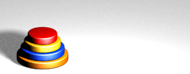

(연습문제)

1. 3개의 원반을 옮기는 순서를 구하는 알고리즘을 구현해 보세요.
2. 4개 원반과 5개 원반을 옯기려면 최소 이동 횟수는 얼마인가?
3. n개의 원반을 옮긴다고 가정했을 때, 계산복잡도는 얼마인가?

#### 6) 순차탐색

- 리스트 안에 있는 원소를 하나씩 순차적으로 비교해가면서 탐색하는 방법입니다
- 아래의 리스트에서 특정 값을 찾아 해당 위치를 반환해주는 알고리즘을 구현해 보세요

  s = [1, 23, 44, 52, 34, 11, 21, 45, 66, 4, 52]  
  x = 44 or 52 or 999

(**연습문제**)

1. 아래 리스트 중에서 x가 존재하는 경우 모든 위치를 반환하는 알고리즘을 만들어 보세요.

   s = [1, 23, 44, 52, 34, 11, 21, 45, 66, 4, 52]  
   x = 52

#### 7) 선택정렬

- 자료를 크기 순서대로 맞춰 일렬로 나열하는 것입니다
- 정렬은 선택정렬 뿐만 아니라 삽입정렬, 병합정렬, 퀵 정렬, 거품정렬 등 다양한 알고리즘이 있습니다
- 오늘 강의에서는 선택정렬에 대해서 알아봅니다

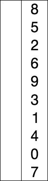

(**연습문제**)

1. 아래 리스트를 오름차순(작은 수에서 큰 수 순서로 나열)으로 정렬하는 선택정렬 알고리즘을 구현해 보세요

   l = [2, 7, 3, 4, 1, 5, 8, 6, 9]
2. 내림차순(큰 수에서 작은 수 순서로 나열)으로 정렬하는 선택정렬 알고리즘을 작성해 보세요.